# Catalog v5.1 location review: events and answers

1512 rows from review_v51_events.csv (PI request 2026-11-25). Built 2026-11-25 16:07 UTC.

**How to use.** 1. Type your name in *Reviewer*. 2. Pick a problem tab or filter the table (problem, automatic rule, tier, status, only events with an event page, text). 3. For each event, open its event page (link or thumbnail; the four report folders must sit next to this file) and fill *earthquake?* (yes / no / unsure), *v5.1 depth* (plausible / implausible / cannot_tell), an optional corrected depth in km, the *action* (keep / flag_not_earthquake / flag_depth_unreliable / relocate / other) and a comment. Answers are saved in this browser as you type. 4. Click *Download CSV* and send the file back: it has every row and the same columns as review_v51_events.csv. To continue later or merge several reviewers, load one or more CSVs with *Load CSV* (this viewer's CSV or a report page's CSV); an event answered differently by two reviewers is kept as it is here and listed as a conflict. The column *auto_indicator_rule_not_verdict* names the automatic rules that fired (list below); it is a pointer for the reviewer, not a verdict.

## P1. Deep events under Mount St Helens

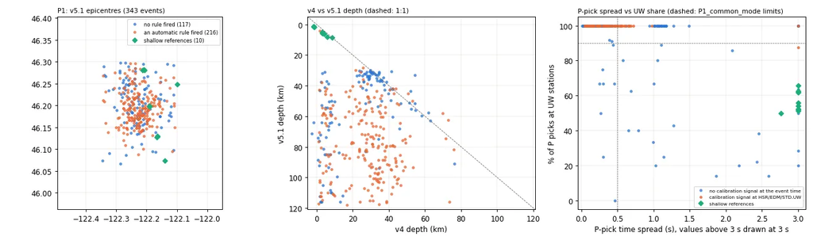

**Time of week of the box events by depth class**

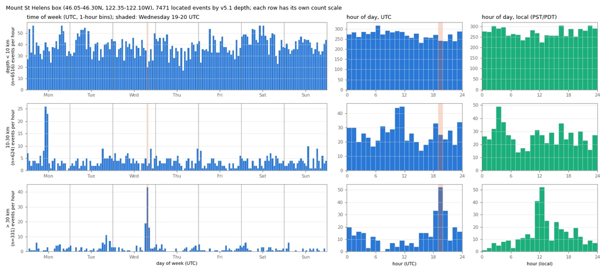

**Weekly scan: quiet stretch at HSR.UW, STD.UW, STD.CC, Wednesdays vs Tuesdays**

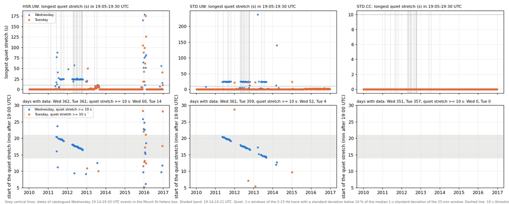

**Raw counts around Wednesday-window events: analog UW vs digital STD.CC**

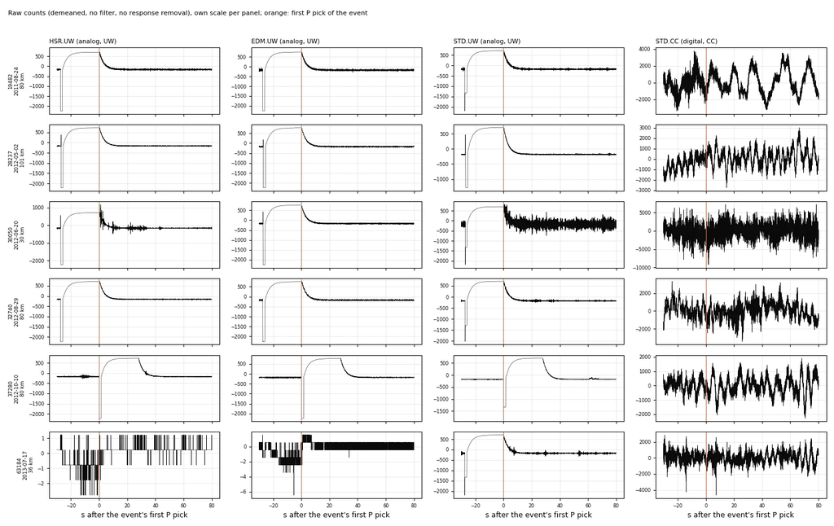

**Automatic rules (the indicator column; not verdicts)**

- **P1_common_mode**: P1: share of P picks at UW stations >= 0.9 AND P-pick time spread <= 0.5 s (farthest P pick > 8 km from the v5.1 epicentre) AND no S pick
- **P1_calibration**: P1: the weekly calibration-type signal at HSR.UW, EDM.UW or STD.UW within 30 s before to 90 s after the v5.1 origin time (a quiet stretch >= 10 s of the 2-15 Hz trace AND a step of the raw trace >= 30 times the median 1-s standard deviation)
- **P1_wed_window**: P1: origin time on a Wednesday 19:14:00-19:20:59 UTC
- **P2_nearest_downweighted**: P2: NonLinLoc weight < 0.1 for an arrival at the nearest station
- **P2_sp_mismatch**: P2: |observed - predicted (v5.1) S-P| > 0.5 s at one of KBO.NC, KSXB.NC, L02D.TA, L02E.TA
- **P2_v4_fits_better**: P2: residual rms (OT refit) of the v4 hypocentre < that of v5.1 - 0.05 s
- **P3_large_move**: P3: v5.1 more than 30 km (3-D) or more than 4 s from the ComCat origin
- **P3_deeper_20km**: P3: v5.1 more than 20 km deeper than ComCat
- **P3_comcat_fits_better**: P3: residual rms (OT refit) of the ComCat hypocentre < that of v5.1 - 0.05 s
- **P4_two_cluster**: P4: the NonLinLoc scatter depths form two clusters (two peaks of a 2-km Gaussian kernel density, at least 10 km apart, the smaller at least 25 % of the larger, the density between them below 50 % of the smaller peak)
- **P4_depth_change_30km**: P4: |v5.1 depth - v4 depth| > 30 km
- **P4_v4_fits_better**: P4: residual rms (OT refit) of the v4 hypocentre < that of v5.1 - 0.05 s
- **P4_sigz_gt_10km**: P4: catalog sig_z > 10 km
- **no_hypocentre**: no v5.1 hypocentre (NonLinLoc did not locate the event)